# Experiment 3

Stas Sajin

October 10, 2015

# Synopsis

The aim of this document is to provide a summary of all the analyses used in writing up the results for Experiment 3 in the dissertation document.The analyses are broken down into several parts:

1. Data Cleaning and Pre-processing
2. Exploratory Analyses
3. Growth Curve Analysis
4. Graphs

#### *Libraries*

Load the required libraries

```r
library(ggplot2)
library(lme4)
library(lmerTest)
library(dplyr)
library(parallel)
library(doParallel)
library(tidyr)
library(gridExtra)
library(caret)
```

#### *Data Loading*

Not all colums in the results file are required. Only the following colums will be loaded in R, so as to preserve memory space. The colums are: RECORDING_SESSION_LABEL, IA_FIRST_RUN_START_TIME, IA_FIRST_RUN_START_TIME, IA_FIRST_RUN_END_TIME, IA_SECOND_RUN_START_TIME, IA_SECOND_RUN_END_TIME, IA_THIRD_RUN_START_TIME, IA_THIRD_RUN_END_TIME, IA_LABEL, RESPONSE_ACC, IA_DWELL_TIME, TRIAL_INDEX, target, RESPONSE_RT,trialtype,target,Bilingual,BUTTON_ACCURACY,EQUASION_RT,sign

```r
EyeData <- read.csv("Exp3DriftCorrected.csv", na.strings = c("."))[,c('RECORDING_SESSION_LABEL', 'IA_FIRST_RUN_START_TIME', 'IA_FIRST_RUN_START_TIME', 'IA_FIRST_RUN_END_TIME', 'IA_SECOND_RUN_START_TIME', 'IA_SECOND_RUN_END_TIME', 'IA_THIRD_RUN_START_TIME', 'IA_THIRD_RUN_END_TIME', 'IA_LABEL', 'RESPONSE_ACC', 'IA_DWELL_TIME', 'TRIAL_INDEX', 'target', 'RESPONSE_RT', 'trialtype','Bilingual','BUTTON_ACCURACY','EQUASION_RT','sign')]
#change all the NAs to zeros
EyeData[is.na(EyeData)] <- 0
#check the dimentions of the dataset
dim(EyeData)
```

```
## [1] 9572   19
```

```r
#rename the RECORDING_SESSION_LABEL into Subject
colnames(EyeData)[1] <- "Subject"
#examine colum names
names(EyeData)
```

```
##  [1] "Subject"                   "IA_FIRST_RUN_START_TIME"
##  [3] "IA_FIRST_RUN_START_TIME.1" "IA_FIRST_RUN_END_TIME"
##  [5] "IA_SECOND_RUN_START_TIME"  "IA_SECOND_RUN_END_TIME"
##  [7] "IA_THIRD_RUN_START_TIME"   "IA_THIRD_RUN_END_TIME"
##  [9] "IA_LABEL"                  "RESPONSE_ACC"
## [11] "IA_DWELL_TIME"             "TRIAL_INDEX"
## [13] "target"                    "RESPONSE_RT"
## [15] "trialtype"                 "Bilingual"
## [17] "BUTTON_ACCURACY"           "EQUASION_RT"
## [19] "sign"
```

Examine the structure of the dataframe

```r
str(EyeData)
```

```
## 'data.frame':    9572 obs. of  19 variables:
##  $ Subject                  : Factor w/ 21 levels "e3s1","e3s10",..: 1 1 1 1 1 1 1 1 1 1 ...
##  $ IA_FIRST_RUN_START_TIME  : num  4556 0 0 0 4572 ...
##  $ IA_FIRST_RUN_START_TIME.1: num  4556 0 0 0 4572 ...
##  $ IA_FIRST_RUN_END_TIME    : num  5038 0 0 0 6242 ...
##  $ IA_SECOND_RUN_START_TIME : num  5884 0 0 0 0 ...
##  $ IA_SECOND_RUN_END_TIME   : num  7334 0 0 0 0 ...
##  $ IA_THIRD_RUN_START_TIME  : num  0 0 0 0 0 0 0 0 0 0 ...
##  $ IA_THIRD_RUN_END_TIME    : num  0 0 0 0 0 0 0 0 0 0 ...
##  $ IA_LABEL                 : Factor w/ 4 levels "COMPET_IA ","TARGET_IA ",..: 2 1 3 4 2 1 3 4 2 1 ...
##  $ RESPONSE_ACC             : int  1 1 1 1 1 1 1 1 1 1 ...
##  $ IA_DWELL_TIME            : int  1936 0 0 0 1652 0 248 0 1824 0 ...
##  $ TRIAL_INDEX              : int  1 1 1 1 2 2 2 2 3 3 ...
##  $ target                   : Factor w/ 114 levels "agree","alarm",..: 104 104 104 104 70 70 70 70 100 100 ...
##  $ RESPONSE_RT              : num  3063 3063 3063 3063 2072 ...
##  $ trialtype                : Factor w/ 4 levels "Experimental",..: 4 4 4 4 4 4 4 4 4 4 ...
##  $ Bilingual                : Factor w/ 2 levels "no","yes": 1 1 1 1 1 1 1 1 1 1 ...
##  $ BUTTON_ACCURACY          : int  1 1 1 1 1 1 1 1 1 1 ...
##  $ EQUASION_RT              : num  4014 4014 4014 4014 1495 ...
##  $ sign                     : Factor w/ 2 levels "-","+": 2 2 2 2 2 2 2 2 1 1 ...
```

Everything looks fine.

# *Data Cleaning and PreProcessing*

Remove practice trials

```r
EyeData <- subset(EyeData, EyeData$trialtype!="Practice")
```

Check subject accuracy and RT for the selection of the word responses

```r
SubjectAccuracy<- EyeData %>% group_by(Subject) %>%
    summarise(MeanAccuracy=mean(RESPONSE_ACC)) %>% arrange(MeanAccuracy)
SubjectAccuracy
```

```
## Source: local data frame [21 x 2]
##
##    Subject MeanAccuracy
## 1     e3s1    0.9814815
## 2     e3s6    0.9814815
## 3    e3s14    0.9907407
## 4    e3s19    0.9907407
## 5     e3s5    0.9907407
## 6    e3s10    1.0000000
## 7    e3s11    1.0000000
## 8    e3s12    1.0000000
## 9    e3s13    1.0000000
## 10   e3s15    1.0000000
## ..     ...          ...
```

```r
mean(SubjectAccuracy$MeanAccuracy)
```

```
## [1] 0.9969136
```

```r
SubjectRT<- EyeData %>% group_by(Subject) %>%
    summarise(MeanRT=mean(RESPONSE_RT)) %>% arrange(MeanRT)
SubjectRT
```

```
## Source: local data frame [21 x 2]
##
##    Subject   MeanRT
## 1     e3s7 1263.187
## 2     e3s4 1271.406
## 3    e3s18 1422.412
## 4    e3s10 1428.523
## 5    e3s11 1456.322
## 6    e3s19 1512.791
## 7     e3s3 1540.068
## 8     e3s6 1564.748
## 9    e3s14 1581.529
## 10    e3s1 1610.379
## ..     ...      ...
```

```r
mean(SubjectRT$MeanRT)
```

```
## [1] 1704.446
```

Subject accuracy is very high. Allmost all the subjects have 100% accuracy. Only several participants showed a few trials with errors.

Now, I examine how well participants solved the problems they were presented on the screen.

```r
SubjectMathAccuracy<- EyeData %>% group_by(Subject) %>%
    summarise(MeanAccuracy=mean(BUTTON_ACCURACY)) %>% arrange(MeanAccuracy)
SubjectMathAccuracy
```

```
## Source: local data frame [21 x 2]
##
##    Subject MeanAccuracy
## 1     e3s6    0.6481481
## 2     e3s3    0.6759259
## 3    e3s15    0.7222222
## 4     e3s4    0.7685185
## 5     e3s1    0.7870370
## 6    e3s10    0.7870370
## 7    e3s16    0.7870370
## 8    e3s18    0.8130841
## 9     e3s9    0.8148148
## 10   e3s11    0.8333333
## ..     ...          ...
```

```r
mean(SubjectMathAccuracy$MeanAccuracy)
```

```
## [1] 0.8284008
```

```r
SubjectMathRT<- EyeData %>% group_by(Subject) %>%
    summarise(MeanRT=mean(EQUASION_RT)) %>% arrange(MeanRT)
SubjectMathRT
```

```
## Source: local data frame [21 x 2]
##
##    Subject    MeanRT
## 1    e3s18  989.5836
## 2     e3s7 1044.7678
## 3    e3s21 1160.6415
## 4     e3s8 1216.7793
## 5    e3s17 1258.5454
## 6     e3s4 1261.7315
## 7    e3s10 1330.0944
## 8    e3s20 1335.8229
## 9    e3s19 1413.8136
## 10   e3s16 1425.0040
## ..     ...       ...
```

```r
mean(SubjectMathRT$MeanRT)
```

```
## [1] 1610.715
```

The accuracy for matho problems is mainly above chance. None of the subjects are removed due to poor accuracy.

Remove trials with incorrect accuracy for word display

```r
CorrectEyeData<-EyeData %>% filter(RESPONSE_ACC==1)
```

Set up the start time and the end time dummy-coding of each run in the interest area. This creates colums where if a fixation exists during a run, then the run gets 1 (exists) or if there is no fixation in the IA during a run, then the coding is 0 (not exist)

```r
CorrectEyeData$Fststart <- ifelse(as.numeric(as.character(CorrectEyeData$IA_FIRST_RUN_START_TIME)) > 0, as.numeric(as.character(CorrectEyeData$IA_FIRST_RUN_START_TIME)), 0)
CorrectEyeData$Fstend <- ifelse(as.numeric(as.character(CorrectEyeData$IA_FIRST_RUN_START_TIME)) > 0, as.numeric(as.character(CorrectEyeData$IA_FIRST_RUN_END_TIME)), 0)
CorrectEyeData$Secstart <- ifelse(as.numeric(as.character(CorrectEyeData$IA_SECOND_RUN_START_TIME)) > 0, as.numeric(as.character(CorrectEyeData$IA_SECOND_RUN_START_TIME)), 0)
CorrectEyeData$Secend <- ifelse(as.numeric(as.character(CorrectEyeData$IA_SECOND_RUN_START_TIME)) > 0, as.numeric(as.character(CorrectEyeData$IA_SECOND_RUN_END_TIME)), 0)
CorrectEyeData$Thirdstart <- ifelse(as.numeric(as.character(CorrectEyeData$IA_THIRD_RUN_START_TIME)) > 0, as.numeric(as.character(CorrectEyeData$IA_THIRD_RUN_START_TIME)), 0)
CorrectEyeData$Thirdend <- ifelse(as.numeric(as.character(CorrectEyeData$IA_THIRD_RUN_START_TIME)) > 0, as.numeric(as.character(CorrectEyeData$IA_THIRD_RUN_END_TIME)), 0)
```

```r
time <- seq(0, 8000, by=25)
tmatrix <- matrix(nrow=nrow(CorrectEyeData), ncol=length(time))
dim(tmatrix)
```

```
## [1] 9040  321
```

Generate time vectors for each row and column for first, second, and third pass viewings so that viewing periods receive a viewing probability value of 1

```r
registerDoParallel(3)
for(i in 1:nrow(tmatrix)) {
for(j in 1:length(time)) {

tmatrix[i,j] <-  ifelse(CorrectEyeData$Fststart[i] < time[j] &
                CorrectEyeData$Fstend[i] > time[j] |CorrectEyeData$Secstart[i] <
                time[j] & CorrectEyeData$Secend[i] > time[j] | CorrectEyeData$Thirdstart[i]
                < time[j] & CorrectEyeData$Thirdend[i]>time[j], 1,0)
}
}
```

Combine the CleanEyeData with the time matrix

```r
CleanData <- cbind(CorrectEyeData, data.frame(tmatrix))
```

Assign time values to time bin columns

```r
colnames(CleanData)[26:346] <- seq(0, 8000, by=25)
```

Subset the dataset with only the necessary colums and remove anything in the memory that might be a memory hog

```r
CleanData <- CleanData[, -c(2:8,10,11,20:25)]
```

Put the data in long-format and then calculate the proportion for each time bin for each subject

```r
CleanData<- CleanData %>% gather(time,value,11:331)
#find proportion for each interest area for each subject
CleanDataProb<-CleanData %>% group_by(Subject,Bilingual,IA_LABEL,trialtype,time) %>%
    summarise(Prob=mean(value))
CleanDataProb$time<-as.numeric(as.character(CleanDataProb$time))
```

# *Exploratory Graphs*

The aim of this section is to explore pattern in the data without commiting to any formal modeling. Several questions will be addressed thoguh exploratory graphs 1. Do participants show smaller competitor effect when they have to solve math problems?

2. How do competitor effects look for problems that participants got right vs problems that they got wrong?
3. How to competitor effects looks for problems that involve substraction (more difficult problems) relative to problems that involve addition.
4. IS there a reason to remove bilingual subjects?

```r
#subset the required dataset by averaging over subjects; find the usual
OnlySubjects<-CleanData %>% group_by(IA_LABEL,trialtype,time) %>%
    summarise(n=n(),Prob=mean(value),sd=sd(value)) %>%
    mutate(se=sd/sqrt(n), LCI=Prob+qnorm(0.025)*se, UCI=Prob+qnorm(0.975)*se)
OnlySubjects$time<-as.numeric(as.character(OnlySubjects$time))

levels(OnlySubjects$IA_LABEL) <- list(Target="TARGET_IA ", Competitor="COMPET_IA ", Distractor1="UNREL1_IA ", Distractor2="UNREL2_IA ")
colnames(OnlySubjects)[1]<-"Interest Area"
```

```r
#plot for time 0 to time 6000
cbPalette <- c("#999999", "#E69F00", "#56B4E9", "#009E73", "#F0E442", "#0072B2", "#D55E00", "#CC79A7")
g1<-ggplot(OnlySubjects, aes(x=time, y=Prob, shape=`Interest Area`, color=`Interest Area`)) +
    geom_point(size=3) +
    geom_errorbar(aes(ymin=LCI, ymax=UCI)) + facet_grid(.~trialtype)+
    scale_x_continuous(limits = c(0, 6000))+
    geom_vline(xintercept = 4200)+
    geom_vline(xintercept = 5500)+theme_bw()+
    scale_fill_manual(values=cbPalette)+scale_colour_manual(values=cbPalette)+
    scale_x_continuous(name="time from onset of fixation cross(ms)")+
    scale_y_continuous(name="Fixation Proportion")+
    theme(legend.text = element_text(size = 12))+
    theme(legend.title = element_text(size=12, face="bold"))+
    theme(legend.title = element_text(size=12, face="bold"))+
    theme(axis.title.x = element_text(face="bold", size=15), axis.text.x  = element_text(size=10))+
    theme(axis.title.y = element_text(face="bold", size=15), axis.text.y  = element_text(size=10))+
    theme(strip.text.x = element_text(size=12, face="bold"))+
    theme(plot.title = element_text(lineheight=.8, face="bold", size=14))

#the display appears around 4s and since it takes about 200ms to initiate and perform the saccade, I look at fixations after 4200ms
g2<-ggplot(OnlySubjects, aes(x=time, y=Prob, shape=`Interest Area`, color=`Interest Area`)) +
    geom_point(size=3) +
    geom_errorbar(aes(ymin=LCI, ymax=UCI)) + facet_grid(.~trialtype)+
    scale_x_continuous(limits = c(4200, 5500), name="time 200ms from onset of word display")+
    theme_bw()+
    scale_fill_manual(values=cbPalette)+scale_colour_manual(values=cbPalette)+
    scale_y_continuous(name="Fixation Proportion")+
    theme(legend.position="none")+
    theme(axis.title.x = element_text(face="bold", size=15), axis.text.x  = element_text(size=10))+
    theme(axis.title.y = element_text(face="bold", size=15), axis.text.y  = element_text(size=10))+
    theme(plot.title = element_text(lineheight=.8, face="bold", size=14))+
    theme(strip.text.x = element_text(size=12, face="bold"))

png(filename="plot1Experiment3.png",width=900,height=524)
grid.arrange(g1, g2, nrow=2, ncol=1, top="Fixation proportion for each trial type for all trials")
dev.off()
```

```r
#subset the required dataset by averaging over subjects; find the usual
CleanData$BUTTON_ACCURACY<-factor(CleanData$BUTTON_ACCURACY)
OnlySubjects<-CleanData %>% group_by(IA_LABEL,trialtype,time, BUTTON_ACCURACY) %>%
    summarise(n=n(),Prob=mean(value),sd=sd(value)) %>%
    mutate(se=sd/sqrt(n), LCI=Prob+qnorm(0.025)*se, UCI=Prob+qnorm(0.975)*se)
OnlySubjects$time<-as.numeric(as.character(OnlySubjects$time))

levels(OnlySubjects$IA_LABEL) <- list(Target="TARGET_IA ", Competitor="COMPET_IA ", Distractor1="UNREL1_IA ", Distractor2="UNREL2_IA ")
colnames(OnlySubjects)[1]<-"Interest Area"
```

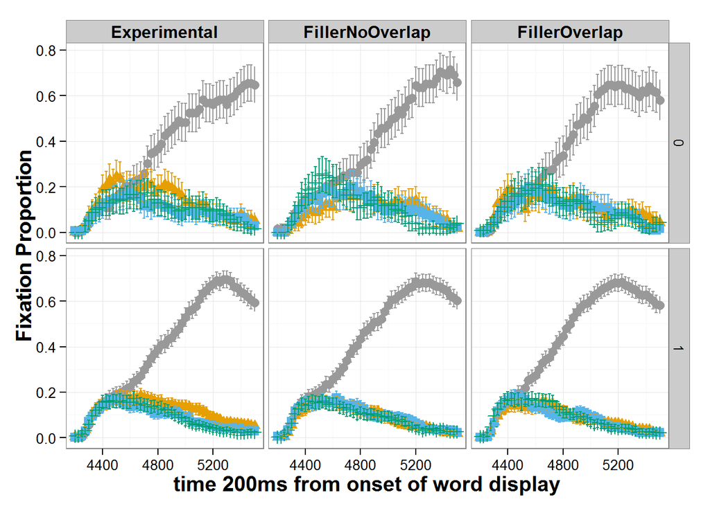

```r
#the display appears around 4s and since it takes about 200ms to initiate and perform the saccade, I look at fixations after 4200ms
ggplot(OnlySubjects, aes(x=time, y=Prob, shape=`Interest Area`, color=`Interest Area`)) +
    geom_point(size=3) +
    geom_errorbar(aes(ymin=LCI, ymax=UCI)) + facet_grid(BUTTON_ACCURACY~trialtype)+
    scale_x_continuous(limits = c(4200, 5500), name="time 200ms from onset of word display")+
    theme_bw()+
    scale_fill_manual(values=cbPalette)+scale_colour_manual(values=cbPalette)+
    scale_y_continuous(name="Fixation Proportion")+
    theme(legend.position="none")+
    theme(axis.title.x = element_text(face="bold", size=15), axis.text.x  = element_text(size=10))+
    theme(axis.title.y = element_text(face="bold", size=15), axis.text.y  = element_text(size=10))+
    theme(plot.title = element_text(lineheight=.8, face="bold", size=14))+
    theme(strip.text.x = element_text(size=12, face="bold"))
```

In the graph above there doesn’t seem to major differences betwen trials they got right and those they got wrong. It is fairly difficult to discern the patterns largely because they got the majority of the trials correct, so there are much fewer datapoints for the incorrect trials.

In the graph below, I will look at trials that had addition vs. trials that had substraction

```r
#subset the required dataset by averaging over subjects; find the usual
OnlySubjects<-CleanData %>% group_by(IA_LABEL,trialtype,time, sign) %>%
    summarise(n=n(),Prob=mean(value),sd=sd(value)) %>%
    mutate(se=sd/sqrt(n), LCI=Prob+qnorm(0.025)*se, UCI=Prob+qnorm(0.975)*se)
OnlySubjects$time<-as.numeric(as.character(OnlySubjects$time))

levels(OnlySubjects$IA_LABEL) <- list(Target="TARGET_IA ", Competitor="COMPET_IA ", Distractor1="UNREL1_IA ", Distractor2="UNREL2_IA ")
colnames(OnlySubjects)[1]<-"Interest Area"
```

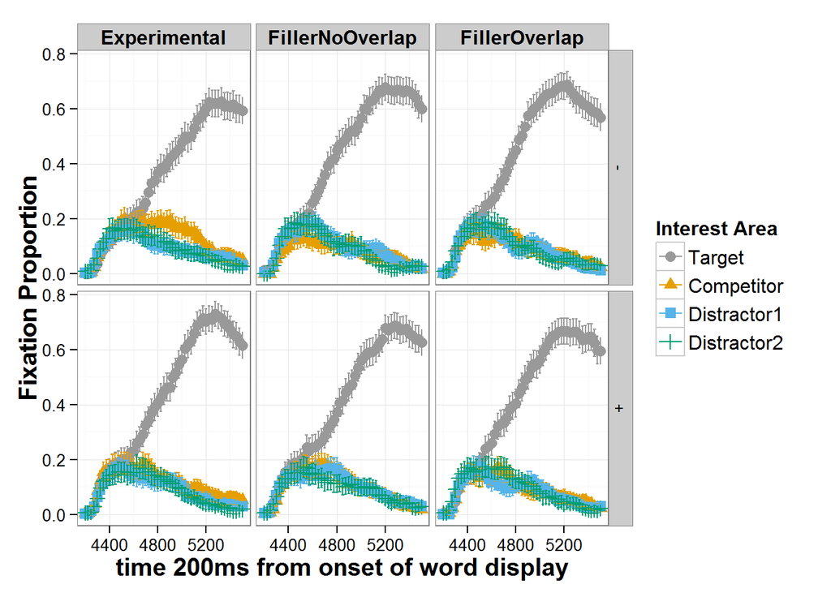

```r
#the display appears around 4s and since it takes about 200ms to initiate and perform the saccade, I look at fixations after 4200ms
ggplot(OnlySubjects, aes(x=time, y=Prob, shape=`Interest Area`, color=`Interest Area`)) +
    geom_point(size=3) +
    geom_errorbar(aes(ymin=LCI, ymax=UCI)) + facet_grid(sign~trialtype)+
    scale_x_continuous(limits = c(4200, 5500), name="time 200ms from onset of word display")+
    theme_bw()+
    scale_fill_manual(values=cbPalette)+scale_colour_manual(values=cbPalette)+
    scale_y_continuous(name="Fixation Proportion")+
    theme(legend.text = element_text(size = 12))+
    theme(legend.title = element_text(size=12, face="bold"))+
    theme(legend.title = element_text(size=12, face="bold"))+
    theme(axis.title.x = element_text(face="bold", size=15), axis.text.x  = element_text(size=10))+
    theme(axis.title.y = element_text(face="bold", size=15), axis.text.y  = element_text(size=10))+
    theme(plot.title = element_text(lineheight=.8, face="bold", size=14))+
    theme(strip.text.x = element_text(size=12, face="bold"))
```

For substraction trials, there seems to be a trend towards a competitor effect. In addition trials, there seems to be no competitor effect whasever. It might be possible that for trials people manage to solve during the presentation of the problem (which are likely to be addition problems) people have more interference from the solution they are storing in mind. Next, I will look at a graph that will examine only competitor trials and will compare the grid of sign and whether people got the problem correct.

```r
#subset the required dataset by averaging over subjects; find the usual
OnlySubjects<-CleanData %>% group_by(IA_LABEL,time, sign, BUTTON_ACCURACY) %>%
    summarise(n=n(),Prob=mean(value),sd=sd(value)) %>%
    mutate(se=sd/sqrt(n), LCI=Prob+qnorm(0.025)*se, UCI=Prob+qnorm(0.975)*se)
OnlySubjects$time<-as.numeric(as.character(OnlySubjects$time))

levels(OnlySubjects$IA_LABEL) <- list(Target="TARGET_IA ", Competitor="COMPET_IA ", Distractor1="UNREL1_IA ", Distractor2="UNREL2_IA ")
colnames(OnlySubjects)[1]<-"Interest Area"
```

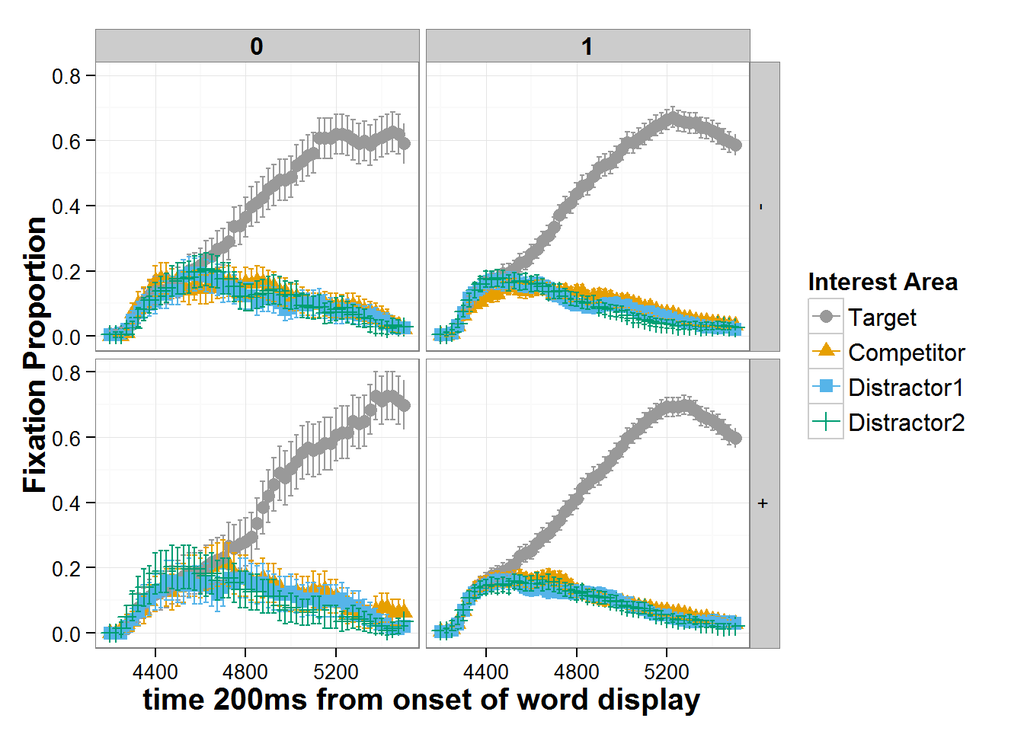

```r
#the display appears around 4s and since it takes about 200ms to initiate and perform the saccade, I look at fixations after 4200ms
ggplot(OnlySubjects, aes(x=time, y=Prob, shape=`Interest Area`, color=`Interest Area`)) +
    geom_point(size=3) +
    geom_errorbar(aes(ymin=LCI, ymax=UCI)) + facet_grid(sign~BUTTON_ACCURACY)+
    scale_x_continuous(limits = c(4200, 5500), name="time 200ms from onset of word display")+
    theme_bw()+
    scale_fill_manual(values=cbPalette)+scale_colour_manual(values=cbPalette)+
    scale_y_continuous(name="Fixation Proportion")+
    theme(legend.text = element_text(size = 12))+
    theme(legend.title = element_text(size=12, face="bold"))+
    theme(legend.title = element_text(size=12, face="bold"))+
    theme(axis.title.x = element_text(face="bold", size=15), axis.text.x  = element_text(size=10))+
    theme(axis.title.y = element_text(face="bold", size=15), axis.text.y  = element_text(size=10))+
    theme(plot.title = element_text(lineheight=.8, face="bold", size=14))+
    theme(strip.text.x = element_text(size=12, face="bold"))
```

No discernible relationship seem to be present in the graph.

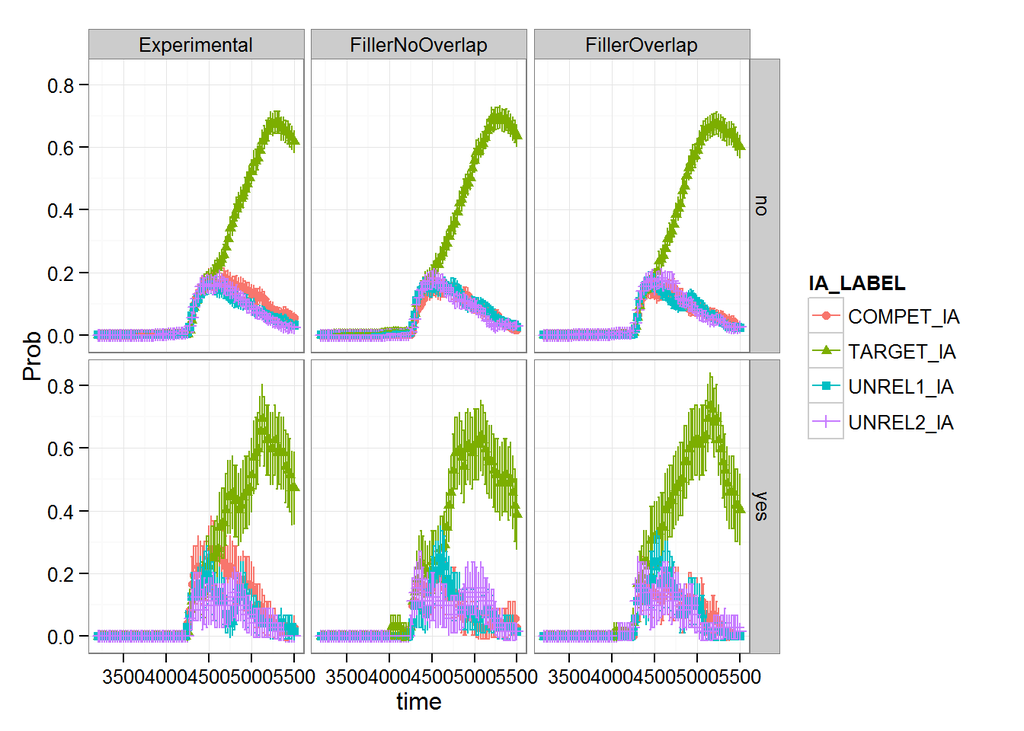

```r
OnlySubjectsB<-CleanData %>% group_by(Bilingual,IA_LABEL,trialtype,time) %>%
    summarise(n=n(),Prob=mean(value),sd=sd(value)) %>%
    mutate(se=sd/sqrt(n), LCI=Prob+qnorm(0.025)*se, UCI=Prob+qnorm(0.975)*se)
OnlySubjectsB$time<-as.numeric(as.character(OnlySubjectsB$time))

ggplot(OnlySubjectsB, aes(x=time, y=Prob, shape=IA_LABEL, color=IA_LABEL)) +
    geom_point() +
    geom_errorbar(aes(ymin=LCI, ymax=UCI)) + facet_grid(Bilingual~trialtype)+
    scale_x_continuous(limits = c(3200, 5500))+
    theme_bw()
```

There doesn’t seem to be any substantial differences between bilinguals and natives. Bilinguals show a bit more competition, but it is important to keep in mind that there were only two bilinguals in the study.

# *Growth Curve Analyses and RF*

The following analyses will examine 1. the proportion fixations between the Target and the Competitor in Experimental Trials 2. the proportion fixations between the Competitor and the average of the two distractors in Experimental Trials.

Based on exploratory graphs, the fixations are examined from 4200 till 5500ms.

## *Target vs. Competitor*

First, the required subset for the `1st` analysis is created

```r
model<-CleanDataProb %>%
    filter(trialtype=="Experimental", IA_LABEL=="COMPET_IA " | IA_LABEL=="TARGET_IA ",
           time>=4200 & time <=5500)
model$IA_LABEL<-as.factor(as.character(model$IA_LABEL))

#Generate time polynomials up to quadratic poly.
t25 <- data.frame(poly(unique(model$time),4))
t25$time <- seq(4200, 5500, by=25)

#add polynomials to data frame
model <- merge(model , t25, by="time")
head(model)
```

```
##   time Subject Bilingual   IA_LABEL    trialtype Prob         X1        X2
## 1 4200    e3s1        no COMPET_IA  Experimental    0 -0.2334681 0.2902389
## 2 4200    e3s3        no TARGET_IA  Experimental    0 -0.2334681 0.2902389
## 3 4200    e3s3        no COMPET_IA  Experimental    0 -0.2334681 0.2902389
## 4 4200   e3s15        no TARGET_IA  Experimental    0 -0.2334681 0.2902389
## 5 4200   e3s21        no COMPET_IA  Experimental    0 -0.2334681 0.2902389
## 6 4200    e3s8        no TARGET_IA  Experimental    0 -0.2334681 0.2902389
##           X3        X4
## 1 -0.3244969 0.3411485
## 2 -0.3244969 0.3411485
## 3 -0.3244969 0.3411485
## 4 -0.3244969 0.3411485
## 5 -0.3244969 0.3411485
## 6 -0.3244969 0.3411485
```

```r
str(model)
```

```
## 'data.frame':    2226 obs. of  10 variables:
##  $ time     : num  4200 4200 4200 4200 4200 4200 4200 4200 4200 4200 ...
##  $ Subject  : Factor w/ 21 levels "e3s1","e3s10",..: 1 15 15 7 14 20 12 4 19 18 ...
##  $ Bilingual: Factor w/ 2 levels "no","yes": 1 1 1 1 1 1 1 1 2 1 ...
##  $ IA_LABEL : Factor w/ 2 levels "COMPET_IA ","TARGET_IA ": 1 2 1 2 1 2 2 2 1 2 ...
##  $ trialtype: Factor w/ 4 levels "Experimental",..: 1 1 1 1 1 1 1 1 1 1 ...
##  $ Prob     : num  0 0 0 0 0 0 0 0 0 0 ...
##  $ X1       : num  -0.233 -0.233 -0.233 -0.233 -0.233 ...
##  $ X2       : num  0.29 0.29 0.29 0.29 0.29 ...
##  $ X3       : num  -0.324 -0.324 -0.324 -0.324 -0.324 ...
##  $ X4       : num  0.341 0.341 0.341 0.341 0.341 ...
```

The following models are run, with increasing complexity:

Model 1: A base model with no polynomials and only with the fixed effect IA_LABEL and random effect of subject intercept and nested condition with subject intercept.

Model 2: Base model with the addition of the linear polynomial for the fixed and random effect structure

Model 3. Model above+the addition of the quadratic polynomial in the fixed effect and random effect structure

Model 4. Model 3+addition of the third poly in the fixed and random effect structure. Model fails to converge

Model 5. Model 4+addition of the third poly in the fixed and in the random structure(subject only); fails to converge

Model 6. Model 4+addition of the third poly in the fixed and random; fails to converge structure(subject:condition only)

```r
registerDoParallel(3)
#base model; Model1
Model1<-lmer(Prob ~ IA_LABEL +
                 (1| Subject) +
                 (1| Subject:IA_LABEL),
               data=model, REML=T)
#linear; model 2
Model2<-lmer(Prob ~ IA_LABEL*X1 +
                 (1+X1| Subject) +
                 (1+X1| Subject:IA_LABEL),
               data=model, REML=T)
#linea+quadratic; model 3
Model3<-lmer(Prob ~ IA_LABEL*(X1+X2) +
                 (1+X1+X2| Subject) +
                 (1+X1+X2| Subject:IA_LABEL),
               data=model, REML=T)
#Model 4
Model4<-lmer(Prob ~ IA_LABEL*(X1+X2+X3) +
                 (1+X1+X2+X3| Subject) +
                 (1+X1+X2+X3| Subject:IA_LABEL),
               data=model, REML=T)
#Model 5
Model5<-lmer(Prob ~ IA_LABEL*(X1+X2+X3) +
                 (1+X1+X2+X3| Subject) +
                 (1+X1+X2| Subject:IA_LABEL),
               data=model, REML=T)
#Model 6
Model6<-lmer(Prob ~ IA_LABEL*(X1+X2+X3) +
                 (1+X1+X2| Subject) +
                 (1+X1+X2+X3| Subject:IA_LABEL),
               data=model, REML=T)
#compare the models based on ANOVA test
anova(Model1,Model2,Model3,Model4,Model5,Model6)
```

```
## Data: model
## Models:
## object: Prob ~ IA_LABEL + (1 | Subject) + (1 | Subject:IA_LABEL)
## ..1: Prob ~ IA_LABEL * X1 + (1 + X1 | Subject) + (1 + X1 | Subject:IA_LABEL)
## ..2: Prob ~ IA_LABEL * (X1 + X2) + (1 + X1 + X2 | Subject) + (1 +
## ..2:     X1 + X2 | Subject:IA_LABEL)
## ..4: Prob ~ IA_LABEL * (X1 + X2 + X3) + (1 + X1 + X2 + X3 | Subject) +
## ..4:     (1 + X1 + X2 | Subject:IA_LABEL)
## ..5: Prob ~ IA_LABEL * (X1 + X2 + X3) + (1 + X1 + X2 | Subject) +
## ..5:     (1 + X1 + X2 + X3 | Subject:IA_LABEL)
## ..3: Prob ~ IA_LABEL * (X1 + X2 + X3) + (1 + X1 + X2 + X3 | Subject) +
## ..3:     (1 + X1 + X2 + X3 | Subject:IA_LABEL)
##        Df     AIC     BIC logLik deviance     Chisq Chi Df Pr(>Chisq)
## object  5 -1258.4 -1229.9  634.2  -1268.4
## ..1    11 -4536.1 -4473.3 2279.1  -4558.1 3289.6944      6     <2e-16 ***
## ..2    19 -5762.5 -5654.1 2900.3  -5800.5 1242.4216      8     <2e-16 ***
## ..4    25 -6392.0 -6249.3 3221.0  -6442.0  641.4957      6     <2e-16 ***
## ..5    25 -6838.9 -6696.2 3444.4  -6888.9  446.8476      0     <2e-16 ***
## ..3    29 -6830.9 -6665.3 3444.4  -6888.9    0.0077      4          1
## ---
## Signif. codes:  0 '***' 0.001 '**' 0.01 '*' 0.05 '.' 0.1 ' ' 1
```

```r
#compare the models based on R^2 based on a paper from Xu (http://onlinelibrary.wiley.com/doi/10.1002/sim.1572/abstract)
1-var(residuals(Model1))/(var(model.response(model.frame(Model1))))
```

```
## [1] 0.3972054
```

```r
1-var(residuals(Model2))/(var(model.response(model.frame(Model2))))
```

```
## [1] 0.8746699
```

```r
1-var(residuals(Model3))/(var(model.response(model.frame(Model3))))
```

```
## [1] 0.9340396
```

```r
1-var(residuals(Model4))/(var(model.response(model.frame(Model4))))
```

```
## [1] 0.9628454
```

```r
1-var(residuals(Model5))/(var(model.response(model.frame(Model5))))
```

```
## [1] 0.9526347
```

```r
1-var(residuals(Model6))/(var(model.response(model.frame(Model6))))
```

```
## [1] 0.9628453
```

```r
#find the summary for model 6
summary(Model6)
```

```
## Linear mixed model fit by REML t-tests use Satterthwaite approximations
##   to degrees of freedom [lmerMod]
## Formula: Prob ~ IA_LABEL * (X1 + X2 + X3) + (1 + X1 + X2 | Subject) +
##     (1 + X1 + X2 + X3 | Subject:IA_LABEL)
##    Data: model
##
## REML criterion at convergence: -6846.9
##
## Scaled residuals:
##     Min      1Q  Median      3Q     Max
## -3.9439 -0.6129 -0.0346  0.5951  3.7497
##
## Random effects:
##  Groups           Name        Variance  Std.Dev. Corr
##  Subject:IA_LABEL (Intercept) 0.0021845 0.04674
##                   X1          0.0674194 0.25965   0.36
##                   X2          0.0858298 0.29297  -0.56  0.33
##                   X3          0.0386412 0.19657  -0.24 -0.41  0.40
##  Subject          (Intercept) 0.0004328 0.02080
##                   X1          0.0036136 0.06011  -1.00
##                   X2          0.0051287 0.07161  -1.00  1.00
##  Residual                     0.0021000 0.04583
## Number of obs: 2226, groups:  Subject:IA_LABEL, 42; Subject, 21
##
## Fixed effects:
##                       Estimate Std. Error       df t value Pr(>|t|)
## (Intercept)            0.11975    0.01125 39.46000  10.646 3.64e-13 ***
## IA_LABELTARGET_IA      0.27222    0.01455 33.32000  18.704  < 2e-16 ***
## X1                    -0.10963    0.05901 40.12000  -1.858 0.070560 .
## X2                    -0.31456    0.06657 40.39000  -4.725 2.78e-05 ***
## X3                     0.18312    0.04405 40.00000   4.158 0.000165 ***
## IA_LABELTARGET_IA :X1  1.69190    0.08137 38.28000  20.793  < 2e-16 ***
## IA_LABELTARGET_IA :X2  0.08035    0.09151 37.76000   0.878 0.385474
## IA_LABELTARGET_IA :X3 -0.40608    0.06229 40.00000  -6.519 8.82e-08 ***
## ---
## Signif. codes:  0 '***' 0.001 '**' 0.01 '*' 0.05 '.' 0.1 ' ' 1
##
## Correlation of Fixed Effects:
##                      (Intr) IA_LAB X1     X2     X3
## IA_LABELTAR          -0.647
## X1                    0.221 -0.240
## X2                   -0.584  0.378  0.361
## X3                   -0.215  0.166 -0.379  0.376
## IA_LABELTARGET_IA:X1 -0.226  0.349 -0.689 -0.224  0.275
## IA_LABELTARGET_IA:X2  0.356 -0.550 -0.224 -0.687 -0.274
## IA_LABELTARGET_IA:X3  0.152 -0.235  0.268 -0.266 -0.707
##                      IA_LABELTARGET_IA:X1 IA_LABELTARGET_IA:X2
## IA_LABELTAR
## X1
## X2
## X3
## IA_LABELTARGET_IA:X1
## IA_LABELTARGET_IA:X2  0.325
## IA_LABELTARGET_IA:X3 -0.388                0.387
```

```r
#find the RMSE
sqrt(mean((model$Prob-fitted(Model6))^2))
```

```
## [1] 0.04424595
```

```r
#attach the fitted values to the dataset model, so that they can be used later for graphing purposes
model$Model1Fitted<-fitted(Model1)
model$Model2Fitted<-fitted(Model2)
model$Model3Fitted<-fitted(Model3)
model$Model4Fitted<-fitted(Model4)
model$Model5Fitted<-fitted(Model5)
model$Model6Fitted<-fitted(Model6)

#check that the values are in the dataset
str(model)
```

```
## 'data.frame':    2226 obs. of  16 variables:
##  $ time        : num  4200 4200 4200 4200 4200 4200 4200 4200 4200 4200 ...
##  $ Subject     : Factor w/ 21 levels "e3s1","e3s10",..: 1 15 15 7 14 20 12 4 19 18 ...
##  $ Bilingual   : Factor w/ 2 levels "no","yes": 1 1 1 1 1 1 1 1 2 1 ...
##  $ IA_LABEL    : Factor w/ 2 levels "COMPET_IA ","TARGET_IA ": 1 2 1 2 1 2 2 2 1 2 ...
##  $ trialtype   : Factor w/ 4 levels "Experimental",..: 1 1 1 1 1 1 1 1 1 1 ...
##  $ Prob        : num  0 0 0 0 0 0 0 0 0 0 ...
##  $ X1          : num  -0.233 -0.233 -0.233 -0.233 -0.233 ...
##  $ X2          : num  0.29 0.29 0.29 0.29 0.29 ...
##  $ X3          : num  -0.324 -0.324 -0.324 -0.324 -0.324 ...
##  $ X4          : num  0.341 0.341 0.341 0.341 0.341 ...
##  $ Model1Fitted: num  0.1288 0.3884 0.1418 0.3698 0.0836 ...
##  $ Model2Fitted: num  0.2011 -0.0862 0.2417 0.0471 0.0175 ...
##  $ Model3Fitted: num  0.096 -0.0372 0.1122 0.021 0.0236 ...
##  $ Model4Fitted: num  -0.012009 0.059434 -0.028511 -0.000206 0.008187 ...
##  $ Model5Fitted: num  -0.01738 0.00236 0.03027 0.11021 -0.02825 ...
##  $ Model6Fitted: num  -0.011735 0.059463 -0.028401 -0.000275 0.008192 ...
```

Model 6 performs the best when examining the R^2 value, though LMER is not very susceptible to corss-validation, so the addition of more polynomials might be leading to overfitting. More complex models could not be fitted due to convergence issues.

### *Compare LMER with Random Forests*

This portion of the report aims to examine if it is even necessary to have so many polynomials in the fixed effect structure of the LMER model used above. Two random forests models are fitted. The models are cross-validated.

The first models examines the inclusion of all 4 polynomials interacting with the IA_LABEL and the inclusion of Subject ID

```r
set.seed(123)
modelRF1<-train(Prob~(X1+X2+X3+X4)*IA_LABEL+Subject, method="rf", data=model,
                trControl = trainControl(method = "cv", number = 5),
                 ntree = 200, importance = TRUE)
#Examine Model Ouput
modelRF1
```

```
## Random Forest
##
## 2226 samples
##   15 predictor
##
## No pre-processing
## Resampling: Cross-Validated (5 fold)
##
## Summary of sample sizes: 1782, 1780, 1781, 1780, 1781
##
## Resampling results across tuning parameters:
##
##   mtry  RMSE        Rsquared   RMSE SD      Rsquared SD
##    2    0.07820164  0.9066250  0.001921562  0.011461839
##   15    0.03841490  0.9727581  0.001610276  0.002046611
##   29    0.03738065  0.9740664  0.001810454  0.002543605
##
## RMSE was used to select the optimal model using  the smallest value.
## The final value used for the model was mtry = 29.
```

```r
#Examine the best model
modelRF1$finalModel
```

```
##
## Call:
##  randomForest(x = x, y = y, ntree = 200, mtry = param$mtry, importance = TRUE)
##                Type of random forest: regression
##                      Number of trees: 200
## No. of variables tried at each split: 29
##
##           Mean of squared residuals: 0.001131292
##                     % Var explained: 97.85
```

```r
#Examine Variable Importance
modelRF1$finalModel$importance
```

```
##                            %IncMSE IncNodePurity
## X1                    0.0042600437     2.5786510
## X2                    0.0043006052     4.3679126
## X3                    0.0014897586     1.0729993
## X4                    0.0008450758     0.8023687
## IA_LABELTARGET_IA     0.0001499538     0.1106075
## Subjecte3s10          0.0015198204     0.8280023
## Subjecte3s11          0.0006992225     0.4937559
## Subjecte3s12          0.0002518831     0.2784800
## Subjecte3s13          0.0002406832     0.1915401
## Subjecte3s14          0.0010660145     1.1135085
## Subjecte3s15          0.0009875542     0.6982643
## Subjecte3s16          0.0005462182     0.4455692
## Subjecte3s17          0.0010295100     0.9844109
## Subjecte3s18          0.0003800196     0.2492013
## Subjecte3s19          0.0009635672     0.9555498
## Subjecte3s2           0.0009851303     0.5741183
## Subjecte3s20          0.0009411030     0.5931211
## Subjecte3s21          0.0017645563     1.1747864
## Subjecte3s3           0.0002983617     0.3929859
## Subjecte3s4           0.0011576788     1.0038632
## Subjecte3s5           0.0005194599     0.4046254
## Subjecte3s6           0.0008571044     0.5702186
## Subjecte3s7           0.0022148347     1.5582662
## Subjecte3s8           0.0008754645     0.7136062
## Subjecte3s9           0.0003002464     0.2867806
## X1:IA_LABELTARGET_IA  0.0839652493    83.6971519
## X2:IA_LABELTARGET_IA  0.0122523766     9.4221105
## X3:IA_LABELTARGET_IA  0.0005219938     0.5646587
## X4:IA_LABELTARGET_IA  0.0004065525     0.4965487
```

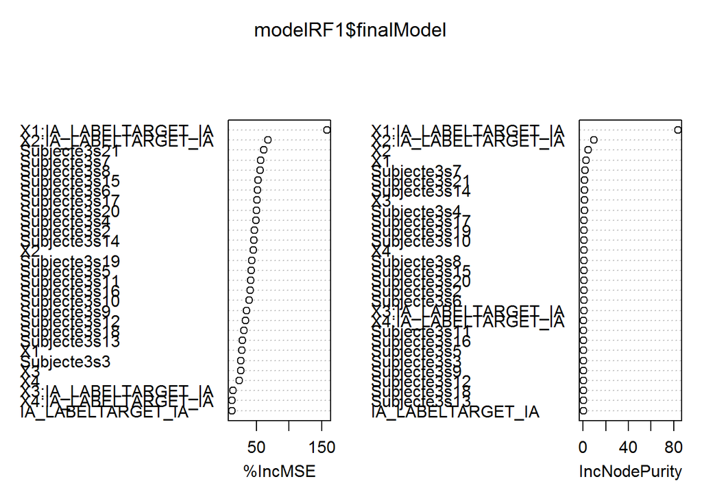

```r
varImpPlot(modelRF1$finalModel)
```

```r
#Examine RMSE
RMSERandomForest<-sqrt(mean((model$Prob-modelRF1$finalModel$predicted)^2))

#attach the predicted values to the dataset for later graphing purposes
model$RF1<-modelRF1$finalModel$predicted
```

The variable importance purity indicator shows that the prediction accuracy is driven primarely by the interaction between linear and quadratic polynomials and condition. This is interesting, because the LMER model doesn not point to an interaction between condition and quadratic polynomyal.

A second model is tested in which higher order polynomials are removed

```r
set.seed(123)
modelRF2<-train(Prob~(X1)*IA_LABEL+Subject, method="rf", data=model,
                trControl = trainControl(method = "cv", number = 5),
                 ntree = 200, importance = TRUE)
#Examine Model Ouput
modelRF2
```

```
## Random Forest
##
## 2226 samples
##   16 predictor
##
## No pre-processing
## Resampling: Cross-Validated (5 fold)
##
## Summary of sample sizes: 1782, 1780, 1781, 1780, 1781
##
## Resampling results across tuning parameters:
##
##   mtry  RMSE        Rsquared   RMSE SD       Rsquared SD
##    2    0.10571401  0.8775272  0.0049965981  0.011392387
##   12    0.03698766  0.9751106  0.0009168028  0.001412729
##   23    0.03229446  0.9807771  0.0012038382  0.001000756
##
## RMSE was used to select the optimal model using  the smallest value.
## The final value used for the model was mtry = 23.
```

```r
#Examine the best model
modelRF2$finalModel
```

```
##
## Call:
##  randomForest(x = x, y = y, ntree = 200, mtry = param$mtry, importance = TRUE)
##                Type of random forest: regression
##                      Number of trees: 200
## No. of variables tried at each split: 23
##
##           Mean of squared residuals: 0.0008257189
##                     % Var explained: 98.43
```

```r
#Examine Variable Importance
modelRF2$finalModel$importance
```

```
##                            %IncMSE IncNodePurity
## X1                    0.0160819542    12.9233411
## IA_LABELTARGET_IA     0.0137909017     3.0926106
## Subjecte3s10          0.0017387480     0.8824874
## Subjecte3s11          0.0007504016     0.6405919
## Subjecte3s12          0.0003146046     0.3039636
## Subjecte3s13          0.0002839788     0.1885447
## Subjecte3s14          0.0011508543     1.1620255
## Subjecte3s15          0.0010966365     0.6913619
## Subjecte3s16          0.0006208078     0.4723278
## Subjecte3s17          0.0011370105     0.9937081
## Subjecte3s18          0.0004402174     0.2474428
## Subjecte3s19          0.0010635830     1.0076935
## Subjecte3s2           0.0010619856     0.5692987
## Subjecte3s20          0.0009770867     0.6045712
## Subjecte3s21          0.0017916485     1.1430054
## Subjecte3s3           0.0003653827     0.4625766
## Subjecte3s4           0.0013142164     1.0574479
## Subjecte3s5           0.0005139381     0.3967351
## Subjecte3s6           0.0009584449     0.6117049
## Subjecte3s7           0.0024263338     1.6179607
## Subjecte3s8           0.0008894954     0.7531686
## Subjecte3s9           0.0003116125     0.2925068
## X1:IA_LABELTARGET_IA  0.0746547840    86.6708836
```

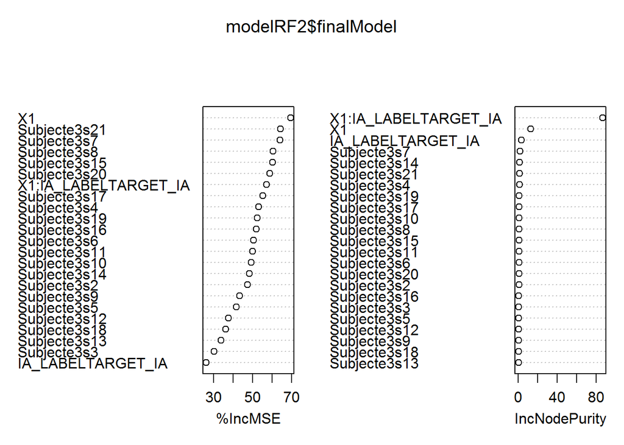

```r
varImpPlot(modelRF2$finalModel)
```

```r
#Examine RMSE
sqrt(mean((model$Prob-modelRF2$finalModel$predicted)^2))
```

```
## [1] 0.02873532
```

```r
#attach the predicted values to the dataset
model$RF2<-modelRF2$finalModel$predicted
```

The model performs really well. And the cross-validaiton performance of the simpler models seems to be better than the one of the more complex model. A suggestion would be to use model 2 or as the model that best describes the data without over-fitting it.

### *Competitor vs. Distractor*

The required subset for the `2nd` analysis is created. This analysis compares the competitor to the average of the two distarctors

```r
#find proportion for each interest area for each subject
levels(CleanData$IA_LABEL) <- list(Distractor="UNREL1_IA ", Distractor="UNREL2_IA ",Competitor="COMPET_IA ", Target="Target_IA ")

CleanDataProb2<-CleanData %>% group_by(Subject,Bilingual,IA_LABEL,trialtype,time) %>%
    summarise(Prob=mean(value))
CleanDataProb2$time<-as.numeric(as.character(CleanDataProb2$time))

modelData<-CleanDataProb2 %>%
    filter(trialtype=="Experimental", IA_LABEL=="Competitor" | IA_LABEL=="Distractor",
           time>=4200 & time <=5500)
modelData$IA_LABEL<-as.factor(as.character(modelData$IA_LABEL))

#Generate time polynomials up to quadratic poly.
t25 <- data.frame(poly(unique(modelData$time),4))
t25$time <- seq(4200, 5500, by=25)

#add polynomials to data frame
modelData <- merge(modelData , t25, by="time")
head(modelData)
```

```
##   time Subject Bilingual   IA_LABEL    trialtype       Prob         X1
## 1 4200    e3s1        no Distractor Experimental 0.00000000 -0.2334681
## 2 4200    e3s3        no Competitor Experimental 0.00000000 -0.2334681
## 3 4200    e3s3        no Distractor Experimental 0.00000000 -0.2334681
## 4 4200   e3s15        no Competitor Experimental 0.00000000 -0.2334681
## 5 4200   e3s21        no Distractor Experimental 0.00000000 -0.2334681
## 6 4200    e3s8        no Competitor Experimental 0.02777778 -0.2334681
##          X2         X3        X4
## 1 0.2902389 -0.3244969 0.3411485
## 2 0.2902389 -0.3244969 0.3411485
## 3 0.2902389 -0.3244969 0.3411485
## 4 0.2902389 -0.3244969 0.3411485
## 5 0.2902389 -0.3244969 0.3411485
## 6 0.2902389 -0.3244969 0.3411485
```

```r
str(modelData)
```

```
## 'data.frame':    2226 obs. of  10 variables:
##  $ time     : num  4200 4200 4200 4200 4200 4200 4200 4200 4200 4200 ...
##  $ Subject  : Factor w/ 21 levels "e3s1","e3s10",..: 1 15 15 7 14 20 12 4 19 18 ...
##  $ Bilingual: Factor w/ 2 levels "no","yes": 1 1 1 1 1 1 1 1 2 1 ...
##  $ IA_LABEL : Factor w/ 2 levels "Competitor","Distractor": 2 1 2 1 2 1 1 1 2 1 ...
##  $ trialtype: Factor w/ 4 levels "Experimental",..: 1 1 1 1 1 1 1 1 1 1 ...
##  $ Prob     : num  0 0 0 0 0 ...
##  $ X1       : num  -0.233 -0.233 -0.233 -0.233 -0.233 ...
##  $ X2       : num  0.29 0.29 0.29 0.29 0.29 ...
##  $ X3       : num  -0.324 -0.324 -0.324 -0.324 -0.324 ...
##  $ X4       : num  0.341 0.341 0.341 0.341 0.341 ...
```

### *Run Growth Curve Analyses*

The following models are run, with increasing complexity: Model 1: A base model with no polynomials and only with the fixed effect IA_LABEL and random effect of subject intercept and nested condition with subject intercept.

Model 2: Base model with the addition of the linear polynomial for the fixed and random effect structure

Model 3. Model above+the addition of the quadratic polynomial in the fixed effect and random effect structure

Model 4. Model 3+addition of the third poly in the fixed and random effect structure.

Model 5. Model 4+addition of the fourth poly in the fixed and in the random structure.

```r
registerDoParallel(3)
#base model; Model1
Model1<-lmer(Prob ~ IA_LABEL +
                 (1| Subject) +
                 (1| Subject:IA_LABEL),
               data=modelData, REML=T)
#linear; model 2
Model2<-lmer(Prob ~ IA_LABEL*X1 +
                 (1+X1| Subject) +
                 (1+X1| Subject:IA_LABEL),
               data=modelData, REML=T)
#linea+quadratic; model 3
Model3<-lmer(Prob ~ IA_LABEL*(X1+X2) +
                 (1+X1+X2| Subject) +
                 (1+X1+X2| Subject:IA_LABEL),
               data=modelData, REML=T)
#Model 4
Model4<-lmer(Prob ~ IA_LABEL*(X1+X2+X3) +
                 (1+X1+X2+X3| Subject) +
                 (1+X1+X2+X3| Subject:IA_LABEL),
               data=modelData, REML=T)
#Model 5
Model5<-lmer(Prob ~ IA_LABEL*(X1+X2+X3+X4) +
                 (1+X1+X2+X3+X4| Subject) +
                 (1+X1+X2+X3+X4| Subject:IA_LABEL),
               data=modelData, REML=T)
#compare the models based on ANOVA test
anova(Model1,Model2,Model3,Model4,Model5)
```

```
## refitting model(s) with ML (instead of REML)
```

```
## Data: modelData
## Models:
## object: Prob ~ IA_LABEL + (1 | Subject) + (1 | Subject:IA_LABEL)
## ..1: Prob ~ IA_LABEL * X1 + (1 + X1 | Subject) + (1 + X1 | Subject:IA_LABEL)
## ..2: Prob ~ IA_LABEL * (X1 + X2) + (1 + X1 + X2 | Subject) + (1 +
## ..2:     X1 + X2 | Subject:IA_LABEL)
## ..3: Prob ~ IA_LABEL * (X1 + X2 + X3) + (1 + X1 + X2 + X3 | Subject) +
## ..3:     (1 + X1 + X2 + X3 | Subject:IA_LABEL)
## ..4: Prob ~ IA_LABEL * (X1 + X2 + X3 + X4) + (1 + X1 + X2 + X3 + X4 |
## ..4:     Subject) + (1 + X1 + X2 + X3 + X4 | Subject:IA_LABEL)
##        Df     AIC     BIC logLik deviance   Chisq Chi Df Pr(>Chisq)
## object  5 -5318.3 -5289.8 2664.2  -5328.3
## ..1    11 -5693.7 -5630.9 2857.9  -5715.7  387.41      6  < 2.2e-16 ***
## ..2    19 -6907.3 -6798.9 3472.7  -6945.3 1229.59      8  < 2.2e-16 ***
## ..3    29 -8164.3 -7998.8 4111.2  -8222.3 1277.02     10  < 2.2e-16 ***
## ..4    41 -8733.9 -8499.8 4407.9  -8815.9  593.54     12  < 2.2e-16 ***
## ---
## Signif. codes:  0 '***' 0.001 '**' 0.01 '*' 0.05 '.' 0.1 ' ' 1
```

```r
#compare the models based on R^2 based on a paper from Xu (http://onlinelibrary.wiley.com/doi/10.1002/sim.1572/abstract)
1-var(residuals(Model1))/(var(model.response(model.frame(Model1))))
```

```
## [1] 0.1248121
```

```r
1-var(residuals(Model2))/(var(model.response(model.frame(Model2))))
```

```
## [1] 0.3061743
```

```r
1-var(residuals(Model3))/(var(model.response(model.frame(Model3))))
```

```
## [1] 0.6253135
```

```r
1-var(residuals(Model4))/(var(model.response(model.frame(Model4))))
```

```
## [1] 0.8049608
```

```r
1-var(residuals(Model5))/(var(model.response(model.frame(Model5))))
```

```
## [1] 0.8591737
```

```r
#find the summary for model 7
summary(Model5)
```

```
## Linear mixed model fit by REML t-tests use Satterthwaite approximations
##   to degrees of freedom [lmerMod]
## Formula: Prob ~ IA_LABEL * (X1 + X2 + X3 + X4) + (1 + X1 + X2 + X3 + X4 |
##     Subject) + (1 + X1 + X2 + X3 + X4 | Subject:IA_LABEL)
##    Data: modelData
##
## REML criterion at convergence: -8750.1
##
## Scaled residuals:
##     Min      1Q  Median      3Q     Max
## -3.4644 -0.5753 -0.0136  0.5540  4.6028
##
## Random effects:
##  Groups           Name        Variance  Std.Dev. Corr
##  Subject:IA_LABEL (Intercept) 0.0003394 0.01842
##                   X1          0.0204087 0.14286  -0.45
##                   X2          0.0165985 0.12883  -0.74  0.11
##                   X3          0.0169719 0.13028   0.49 -0.91 -0.19
##                   X4          0.0125626 0.11208   0.32  0.33 -0.84 -0.19
##  Subject          (Intercept) 0.0001921 0.01386
##                   X1          0.0172747 0.13143   0.14
##                   X2          0.0052585 0.07252  -0.85  0.04
##                   X3          0.0033901 0.05822  -0.03 -0.96 -0.24
##                   X4          0.0011546 0.03398   0.04  0.94 -0.05 -0.84
##  Residual                     0.0008878 0.02980
## Number of obs: 2226, groups:  Subject:IA_LABEL, 42; Subject, 21
##
## Fixed effects:
##                        Estimate Std. Error        df t value Pr(>|t|)
## (Intercept)            0.119747   0.005109 35.620000  23.436  < 2e-16 ***
## IA_LABELDistractor    -0.029888   0.005824 26.520000  -5.132 2.25e-05 ***
## X1                    -0.109629   0.042857 33.320000  -2.558   0.0153 *
## X2                    -0.314560   0.032910 37.970000  -9.558 1.19e-11 ***
## X3                     0.183122   0.031810 39.010000   5.757 1.13e-06 ***
## X4                    -0.042357   0.026372 39.750000  -1.606   0.1162
## IA_LABELDistractor:X1 -0.055706   0.045036 27.590000  -1.237   0.2265
## IA_LABELDistractor:X2  0.080472   0.040809 30.740000   1.972   0.0577 .
## IA_LABELDistractor:X3  0.006808   0.041242 36.730000   0.165   0.8698
## IA_LABELDistractor:X4 -0.022027   0.035791 36.330000  -0.615   0.5421
## ---
```

[output cut: 8 more lines]

```
## X4            0.243 -0.207      0.400 -0.674 -0.255
## IA_LABELD:X1  0.245 -0.430     -0.525 -0.067  0.563 -0.212
## IA_LABELD:X2  0.403 -0.708     -0.057 -0.620  0.114  0.538  0.109
## IA_LABELD:X3 -0.267  0.468      0.456  0.109 -0.648  0.124 -0.869
## IA_LABELD:X4 -0.174  0.305     -0.164  0.492  0.118 -0.679  0.312
##              IA_LABELD:X2 IA_LABELD:X3
## IA_LABELDst
## X1
## X2
## X3
## X4
## IA_LABELD:X1
## IA_LABELD:X2
## IA_LABELD:X3 -0.176
## IA_LABELD:X4 -0.793       -0.182
```

```r
#find the RMSE
sqrt(mean((modelData$Prob-fitted(Model5))^2))
```

```
## [1] 0.02865346
```

```r
#attach the fitted values to the dataset modelData, so that they can be used later for graphing purposes
modelData$Model1Fitted<-fitted(Model1)
modelData$Model2Fitted<-fitted(Model2)
modelData$Model3Fitted<-fitted(Model3)
modelData$Model4Fitted<-fitted(Model4)
modelData$Model5Fitted<-fitted(Model5)
```

Model 5 seems to perform the best, while also converging to a result. Next, I will examine what happens in random forests.

The first models examines the inclusion of all 4 polynomials interacting with the IA_LABEL and the inclusion of Subject ID

```r
set.seed(123)
modelRF1<-train(Prob~(X1+X2+X3+X4)*IA_LABEL+Subject, method="rf", data=modelData,
                trControl = trainControl(method = "cv", number = 5),
                 ntree = 200, importance = TRUE)
#Examine Model Ouput
modelRF1
```

```
## Random Forest
##
## 2226 samples
##   14 predictor
##
## No pre-processing
## Resampling: Cross-Validated (5 fold)
##
## Summary of sample sizes: 1782, 1780, 1780, 1781, 1781
##
## Resampling results across tuning parameters:
##
##   mtry  RMSE        Rsquared   RMSE SD       Rsquared SD
##    2    0.04780412  0.6650926  0.0015347645  0.013914021
##   15    0.02763018  0.8717891  0.0013622317  0.012630026
##   29    0.02683141  0.8786017  0.0007761602  0.007236875
##
## RMSE was used to select the optimal model using  the smallest value.
## The final value used for the model was mtry = 29.
```

```r
#Examine the best model
modelRF1$finalModel
```

```
##
## Call:
##  randomForest(x = x, y = y, ntree = 200, mtry = param$mtry, importance = TRUE)
##                Type of random forest: regression
##                      Number of trees: 200
## No. of variables tried at each split: 29
##
##           Mean of squared residuals: 0.0005916955
##                     % Var explained: 89.85
```

```r
#Examine Variable Importance
modelRF1$finalModel$importance
```

```
##                            %IncMSE IncNodePurity
## X1                    0.0031845560    2.07985932
## X2                    0.0039267203    3.16995217
## X3                    0.0013293051    0.85441051
## X4                    0.0006380587    0.62981977
## IA_LABELDistractor    0.0005084259    0.23140355
## Subjecte3s10          0.0001247901    0.13647476
## Subjecte3s11          0.0004120847    0.24657591
## Subjecte3s12          0.0001707486    0.13381123
## Subjecte3s13          0.0001138912    0.10651247
## Subjecte3s14          0.0001463688    0.16353383
## Subjecte3s15          0.0006257302    0.43802675
## Subjecte3s16          0.0002154835    0.18229468
## Subjecte3s17          0.0003117125    0.22611159
## Subjecte3s18          0.0000589348    0.07628915
## Subjecte3s19          0.0001208167    0.13766917
## Subjecte3s2           0.0003714377    0.30846446
## Subjecte3s20          0.0003144158    0.22457419
## Subjecte3s21          0.0009463290    0.75661433
## Subjecte3s3           0.0001930344    0.19810930
## Subjecte3s4           0.0001504072    0.16975719
## Subjecte3s5           0.0002047477    0.14810725
## Subjecte3s6           0.0003008722    0.22271179
## Subjecte3s7           0.0002341556    0.19757507
## Subjecte3s8           0.0003569519    0.23411217
## Subjecte3s9           0.0001438519    0.13039271
## X1:IA_LABELDistractor 0.0007182247    0.48630420
## X2:IA_LABELDistractor 0.0005216729    0.27559886
## X3:IA_LABELDistractor 0.0004382412    0.31038462
## X4:IA_LABELDistractor 0.0005730716    0.29925212
```

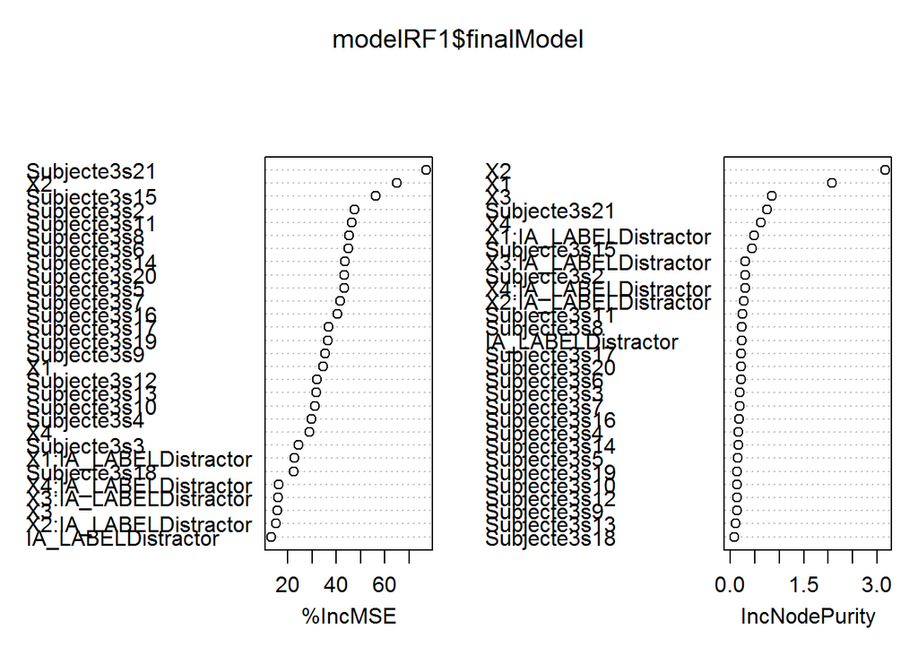

```r
varImpPlot(modelRF1$finalModel)
```

```r
#Examine RMSE
RMSERandomForest<-sqrt(mean((model$Prob-modelRF1$finalModel$predicted)^2))
#attach predicted values
modelData$RF1<-modelRF1$finalModel$predicted
```

The random forest indicates that a lot of interactions between condition and poly might be redundant. A simpler model is tested next.

```r
set.seed(123)
modelRF2<-train(Prob~(X1)*IA_LABEL+Subject, method="rf", data=modelData,
                trControl = trainControl(method = "cv", number = 5),
                 ntree = 200, importance = TRUE)
#Examine Model Ouput
modelRF2
```

```
## Random Forest
##
## 2226 samples
##   15 predictor
##
## No pre-processing
## Resampling: Cross-Validated (5 fold)
##
## Summary of sample sizes: 1782, 1780, 1780, 1781, 1781
##
## Resampling results across tuning parameters:
##
##   mtry  RMSE        Rsquared   RMSE SD      Rsquared SD
##    2    0.05817785  0.5684785  0.001808137  0.01262007
##   12    0.02658461  0.8834950  0.001331770  0.01148810
##   23    0.02366568  0.9054407  0.001530175  0.01017758
##
## RMSE was used to select the optimal model using  the smallest value.
## The final value used for the model was mtry = 23.
```

```r
#Examine the best model
modelRF2$finalModel
```

```
##
## Call:
##  randomForest(x = x, y = y, ntree = 200, mtry = param$mtry, importance = TRUE)
##                Type of random forest: regression
##                      Number of trees: 200
## No. of variables tried at each split: 23
##
##           Mean of squared residuals: 0.0004579427
##                     % Var explained: 92.15
```

```r
#Examine Variable Importance
modelRF2$finalModel$importance
```

```
##                            %IncMSE IncNodePurity
## X1                    7.795022e-03    6.50830375
## IA_LABELDistractor    1.492632e-03    0.36719980
## Subjecte3s10          1.461233e-04    0.14585254
## Subjecte3s11          4.625434e-04    0.34235200
## Subjecte3s12          2.011416e-04    0.15090066
## Subjecte3s13          1.376558e-04    0.10781435
## Subjecte3s14          1.583863e-04    0.16825127
## Subjecte3s15          6.484357e-04    0.40112660
## Subjecte3s16          2.611658e-04    0.19483054
## Subjecte3s17          3.550395e-04    0.24351910
## Subjecte3s18          6.967787e-05    0.07218502
## Subjecte3s19          1.337175e-04    0.14261461
## Subjecte3s2           3.943182e-04    0.33017249
## Subjecte3s20          3.541810e-04    0.23475054
## Subjecte3s21          1.010457e-03    0.70877848
## Subjecte3s3           2.411007e-04    0.26469259
## Subjecte3s4           1.796433e-04    0.18800792
## Subjecte3s5           2.183203e-04    0.15628020
## Subjecte3s6           3.174535e-04    0.24116749
## Subjecte3s7           2.603945e-04    0.21836545
## Subjecte3s8           3.697499e-04    0.21387557
## Subjecte3s9           1.651231e-04    0.12607476
## X1:IA_LABELDistractor 2.084402e-03    1.23272671
```

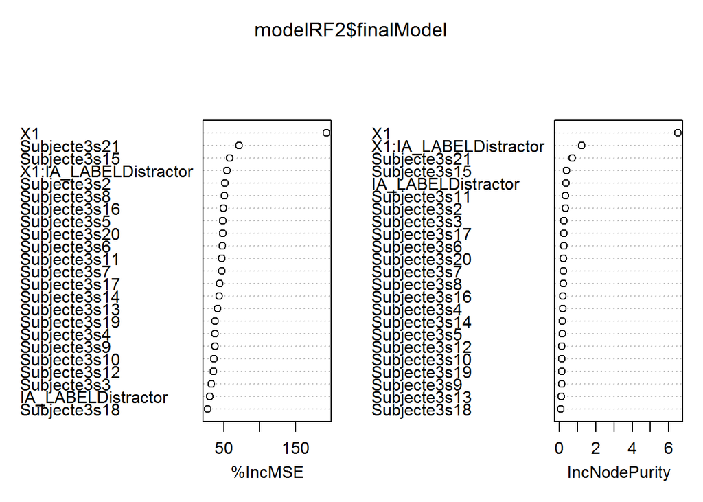

```r
varImpPlot(modelRF2$finalModel)
```

```r
#Examine RMSE
sqrt(mean((modelData$Prob-modelRF2$finalModel$predicted)^2))
```

```
## [1] 0.0213996
```

```r
#attached predicted values
modelData$RF2<-modelRF2$finalModel$predicted
```

The cross-validated random forest model fewer components performs a bit better than the one that has more components. The linear interaction between poly and condiiton becomes significant

## **Graphs**

Each model used above will be graphed by overlaying it on the real data. First, the plots for the first comparison will be created. For this, I use the model dataset. I put the data in long only format.

```r
ModelLong<- model %>% gather(Model,Predictions,11:18)
#rename the competitor and target
levels(ModelLong$IA_LABEL) <- list(Competitor="COMPET_IA ", Target="TARGET_IA ")
#rename the models so that they are more clear
levels(ModelLong$Model) <- list(`Model 1 Intercept`="Model1Fitted", `Model 2 Linear`="Model2Fitted", `Model 3 Quadratic`="Model3Fitted", `Model 4 Cubic (not converged)`="Model4Fitted", `Model 5 Cubic (not converged)`="Model5Fitted", `Model 6 Cubic`="Model6Fitted", `Random Forest Complex`="RF1",`Random Forest Simple`="RF2")

#rename some of the colums
colnames(ModelLong)[4]<-"Interest Area"
ModelLong[,4]<-factor(ModelLong[,4])
#compress the data(find the average over subjects)
ForGraph1<-ModelLong %>% group_by(`Interest Area`,time, Model) %>%
    summarise(`Fixation Probability`=mean(Prob),Predicted=mean(Predictions))
```

The code chunk below will plot and save the graph

```r
#color palette for color-blind
cbPalette <- c("#999999", "#E69F00", "#56B4E9", "#009E73", "#F0E442", "#0072B2", "#D55E00", "#CC79A7")
#create plot1 for Experiment 1, which goes in the publication
png(filename="plot2Experiment3.png",width=900,height=524)
ggplot(ForGraph1, aes(x=time, y=`Fixation Probability`, shape=`Interest Area`, color=`Interest Area`)) +
    geom_point(size=3) + geom_line(aes(y=Predicted), size=1)+facet_wrap(~Model, nrow=2, ncol=4)+
    scale_fill_manual(values=cbPalette)+scale_colour_manual(values=cbPalette)+
    ggtitle("Fixation Proportion for Models\n examining Target vs. Competitor")+
    theme_bw()+
    scale_x_continuous(name="time 200ms from display onset(ms)")+
    theme(legend.text = element_text(size = 12))+
    theme(legend.title = element_text(size=12, face="bold"))+
    theme(axis.title.x = element_text(face="bold", size=15), axis.text.x  = element_text(size=12))+
    theme(axis.title.y = element_text(face="bold", size=15), axis.text.y  = element_text(size=12))+
    theme(strip.text.x = element_text(size=12, face="bold"))+
    theme(plot.title = element_text(lineheight=.8, face="bold", size=14))+
    scale_y_continuous(limits = c(0, 1))
dev.off()
```

Now I will plot the second graph for Competitor vs. average of the two distractors. I will use the same steps as for the graph above

```r
ModelLong<- modelData %>% gather(Model,Predictions,11:17)
#rename the models so that they are more clear
levels(ModelLong$Model) <- list(`Model 1 Intercept`="Model1Fitted", `Model 2 Linear`="Model2Fitted", `Model 3 Quadratic`="Model3Fitted", `Model 4 Cubic`="Model4Fitted", `Model 5 Quartic`="Model5Fitted",`Random Forest Complex`="RF1",`Random Forest Simple`="RF2")

#rename some of the colums
colnames(ModelLong)[4]<-"Interest Area"
ModelLong[,4]<-factor(ModelLong[,4])
#compress the data(find the average over subjects)
ForGraph2<-ModelLong %>% group_by(`Interest Area`,time, Model) %>%
    summarise(`Fixation Probability`=mean(Prob),Predicted=mean(Predictions))
```

The code chunk below will plot and save the graph

```r
#color palette for color-blind
cbPalette <- c("#999999", "#E69F00", "#56B4E9", "#009E73", "#F0E442", "#0072B2", "#D55E00", "#CC79A7")
#create plot1 for Experiment 1, which goes in the publication
png(filename="plot3Experiment3.png",width=900,height=524)
ggplot(ForGraph2, aes(x=time, y=`Fixation Probability`, shape=`Interest Area`, color=`Interest Area`)) +
    geom_point(size=3) + geom_line(aes(y=Predicted), size=1)+facet_wrap(~Model, nrow=2, ncol=4)+
    scale_fill_manual(values=cbPalette)+scale_colour_manual(values=cbPalette)+
    ggtitle("Fixation Proportion for Models\n examining Target vs. Competitor")+
    theme_bw()+
    scale_x_continuous(name="time 200ms from display onset(ms)")+
    theme(legend.text = element_text(size = 12))+
    theme(legend.title = element_text(size=12, face="bold"))+
    theme(axis.title.x = element_text(face="bold", size=15), axis.text.x  = element_text(size=12))+
    theme(axis.title.y = element_text(face="bold", size=15), axis.text.y  = element_text(size=12))+
    theme(strip.text.x = element_text(size=12, face="bold"))+
    theme(plot.title = element_text(lineheight=.8, face="bold", size=14))+
    scale_y_continuous(limits = c(0, 1))
dev.off()
```